# Part I - (Loan Data from Prosper)

## Introduction

> This dataset contains 113,937 loans with 81 variables on each loan, including loan amount, borrower rate (or interest rate), current loan status, borrower income, and many others.

## Preliminary Wrangling

```python
# import all packages and set plots to be embedded inline
import numpy as np
import pandas as pd
import matplotlib.pyplot as plt
import seaborn as sb

%matplotlib inline
```

```python
# load in the dataset into pandas dataframe
df = pd.read_csv('prosperLoanData.csv')
df.head()
```

|  | ListingKey | ListingNumber | ListingCreationDate | CreditGrade | Term | LoanStatus | ClosedDate | BorrowerAPR | BorrowerRate | LenderYield | ... | LP_ServiceFees | LP_CollectionFees | LP_GrossPrincipalLoss | LP_NetPrincipalLoss | LP_NonPrincipalRecoverypayments | PercentFunded | Recommendations | InvestmentFromFriendsCount | InvestmentFromFriendsAmount | Investors |
| --- | --- | --- | --- | --- | --- | --- | --- | --- | --- | --- | --- | --- | --- | --- | --- | --- | --- | --- | --- | --- | --- |
| 0 | 1021339766868145413AB3B | 193129 | 2007-08-26 19:09:29.263000000 | C | 36 | Completed | 2009-08-14 00:00:00 | 0.16516 | 0.1580 | 0.1380 | ... | -133.18 | 0.0 | 0.0 | 0.0 | 0.0 | 1.0 | 0 | 0 | 0.0 | 258 |
| 1 | 10273602499503308B223C1 | 1209647 | 2014-02-27 08:28:07.900000000 | NaN | 36 | Current | NaN | 0.12016 | 0.0920 | 0.0820 | ... | 0.00 | 0.0 | 0.0 | 0.0 | 0.0 | 1.0 | 0 | 0 | 0.0 | 1 |
| 2 | 0EE9337825851032864889A | 81716 | 2007-01-05 15:00:47.090000000 | HR | 36 | Completed | 2009-12-17 00:00:00 | 0.28269 | 0.2750 | 0.2400 | ... | -24.20 | 0.0 | 0.0 | 0.0 | 0.0 | 1.0 | 0 | 0 | 0.0 | 41 |
| 3 | 0EF5356002482715299901A | 658116 | 2012-10-22 11:02:35.010000000 | NaN | 36 | Current | NaN | 0.12528 | 0.0974 | 0.0874 | ... | -108.01 | 0.0 | 0.0 | 0.0 | 0.0 | 1.0 | 0 | 0 | 0.0 | 158 |
| 4 | 0F023589499656230C5E3E2 | 909464 | 2013-09-14 18:38:39.097000000 | NaN | 36 | Current | NaN | 0.24614 | 0.2085 | 0.1985 | ... | -60.27 | 0.0 | 0.0 | 0.0 | 0.0 | 1.0 | 0 | 0 | 0.0 | 20 |

5 rows × 81 columns

```python
# get the dimension of the dataset
df.shape
```

```
(113937, 81)
```

**The above code shows the number of rows(113937) and columns(81) in the dataset**

```python
# check for the datatypes of each columns
df.dtypes
```

```
ListingKey                      object
ListingNumber                    int64
ListingCreationDate             object
CreditGrade                     object
Term                             int64
                                ...
PercentFunded                  float64
Recommendations                  int64
InvestmentFromFriendsCount       int64
InvestmentFromFriendsAmount    float64
Investors                        int64
Length: 81, dtype: object
```

```python
# check for the general the information of the dataset
df.info()
```

```
<class 'pandas.core.frame.DataFrame'>
RangeIndex: 113937 entries, 0 to 113936
Data columns (total 81 columns):
 #   Column                               Non-Null Count   Dtype
---  ------                               --------------   -----
 0   ListingKey                           113937 non-null  object
 1   ListingNumber                        113937 non-null  int64
 2   ListingCreationDate                  113937 non-null  object
 3   CreditGrade                          28953 non-null   object
 4   Term                                 113937 non-null  int64
 5   LoanStatus                           113937 non-null  object
 6   ClosedDate                           55089 non-null   object
 7   BorrowerAPR                          113912 non-null  float64
 8   BorrowerRate                         113937 non-null  float64
 9   LenderYield                          113937 non-null  float64
```

[output cut: 73 more lines]

```python
# check for the satistical information of the dataset
df.describe()
```

|  | ListingNumber | Term | BorrowerAPR | BorrowerRate | LenderYield | EstimatedEffectiveYield | EstimatedLoss | EstimatedReturn | ProsperRating (numeric) | ProsperScore | ... | LP_ServiceFees | LP_CollectionFees | LP_GrossPrincipalLoss | LP_NetPrincipalLoss | LP_NonPrincipalRecoverypayments | PercentFunded | Recommendations | InvestmentFromFriendsCount | InvestmentFromFriendsAmount | Investors |
| --- | --- | --- | --- | --- | --- | --- | --- | --- | --- | --- | --- | --- | --- | --- | --- | --- | --- | --- | --- | --- | --- |
| count | 1.139370e+05 | 113937.000000 | 113912.000000 | 113937.000000 | 113937.000000 | 84853.000000 | 84853.000000 | 84853.000000 | 84853.000000 | 84853.000000 | ... | 113937.000000 | 113937.000000 | 113937.000000 | 113937.000000 | 113937.000000 | 113937.000000 | 113937.000000 | 113937.000000 | 113937.000000 | 113937.000000 |
| mean | 6.278857e+05 | 40.830248 | 0.218828 | 0.192764 | 0.182701 | 0.168661 | 0.080306 | 0.096068 | 4.072243 | 5.950067 | ... | -54.725641 | -14.242698 | 700.446342 | 681.420499 | 25.142686 | 0.998584 | 0.048027 | 0.023460 | 16.550751 | 80.475228 |
| std | 3.280762e+05 | 10.436212 | 0.080364 | 0.074818 | 0.074516 | 0.068467 | 0.046764 | 0.030403 | 1.673227 | 2.376501 | ... | 60.675425 | 109.232758 | 2388.513831 | 2357.167068 | 275.657937 | 0.017919 | 0.332353 | 0.232412 | 294.545422 | 103.239020 |
| min | 4.000000e+00 | 12.000000 | 0.006530 | 0.000000 | -0.010000 | -0.182700 | 0.004900 | -0.182700 | 1.000000 | 1.000000 | ... | -664.870000 | -9274.750000 | -94.200000 | -954.550000 | 0.000000 | 0.700000 | 0.000000 | 0.000000 | 0.000000 | 1.000000 |
| 25% | 4.009190e+05 | 36.000000 | 0.156290 | 0.134000 | 0.124200 | 0.115670 | 0.042400 | 0.074080 | 3.000000 | 4.000000 | ... | -73.180000 | 0.000000 | 0.000000 | 0.000000 | 0.000000 | 1.000000 | 0.000000 | 0.000000 | 0.000000 | 2.000000 |
| 50% | 6.005540e+05 | 36.000000 | 0.209760 | 0.184000 | 0.173000 | 0.161500 | 0.072400 | 0.091700 | 4.000000 | 6.000000 | ... | -34.440000 | 0.000000 | 0.000000 | 0.000000 | 0.000000 | 1.000000 | 0.000000 | 0.000000 | 0.000000 | 44.000000 |
| 75% | 8.926340e+05 | 36.000000 | 0.283810 | 0.250000 | 0.240000 | 0.224300 | 0.112000 | 0.116600 | 5.000000 | 8.000000 | ... | -13.920000 | 0.000000 | 0.000000 | 0.000000 | 0.000000 | 1.000000 | 0.000000 | 0.000000 | 0.000000 | 115.000000 |
| max | 1.255725e+06 | 60.000000 | 0.512290 | 0.497500 | 0.492500 | 0.319900 | 0.366000 | 0.283700 | 7.000000 | 11.000000 | ... | 32.060000 | 0.000000 | 25000.000000 | 25000.000000 | 21117.900000 | 1.012500 | 39.000000 | 33.000000 | 25000.000000 | 1189.000000 |

8 rows × 61 columns

### What is the structure of your dataset?

> This dataset consists of 113,937 rows/loans and 81 columns/variables. Prosperscore is dependents on most of the other variables and most of the independent variables are of float datatypes. Some variables such as ProsperScore(Ordinal), employmentStatus(Norminal), and IncomeVerifiable are categorical.

### What is/are the main feature(s) of interest in your dataset?

> Area of interest is checking for the variables that will affect the properScore(which is our dependent variable) of a borrower.

### What features in the dataset do you think will help support your investigation into your feature(s) of interest?

> IncomeRange, IncomeVerifiable, EmploymentStatus, Recomendations, OnTimeProsperPayments and isBorrowerHomeOwner are some of the variables ProsperScore depends on.

#### Programmatic Assesssment of the Dependent Variable (ProsperScore)

```python
# check for missing values
df['ProsperScore'].isnull().sum()
```

```
29084
```

```python
# drop the missing values as they won't be needed for the analysis
df = df.query('ProsperScore.notnull()')
```

```python
# check if the change has been made
df['ProsperScore'].isnull().sum().any()
```

```
False
```

```python
# check for the datatype
df['ProsperScore'].dtypes
```

```
dtype('float64')
```

```python
# change data type from float to integer
df['ProsperScore'] = df['ProsperScore'].astype(np.int64)
```

```python
# check for the change
df['ProsperScore'].dtypes
```

```
dtype('int64')
```

```python
# check for the general info of the dependent variable
df['ProsperScore'].info()
```

```
<class 'pandas.core.series.Series'>
Int64Index: 84853 entries, 1 to 113936
Series name: ProsperScore
Non-Null Count  Dtype
--------------  -----
84853 non-null  int64
dtypes: int64(1)
memory usage: 1.3 MB
```

```python
# the highest score from the data description is 10 so, i would check if there is any score greater
df['ProsperScore'].max()
```

```
11
```

```python
# replace values greater than 10 with 10
df['ProsperScore'] = df['ProsperScore'].replace(11, 10)
df['ProsperScore'].max()
```

```
10
```

## Univariate Exploration

#### Plot distribution of key variable of interest (ProsperScore)

```python
# function to plot bar chart
def hist(DataFrame, variable, x_label, title):
#Add figure size
    plt.figure(figsize = [14, 6])
    base_color = sb.color_palette()[1]
    sb.countplot(data=DataFrame, x=variable, color  = base_color );
    plt.xlabel(x_label)
    plt.title(title, fontsize=16)
    plt.show()
```

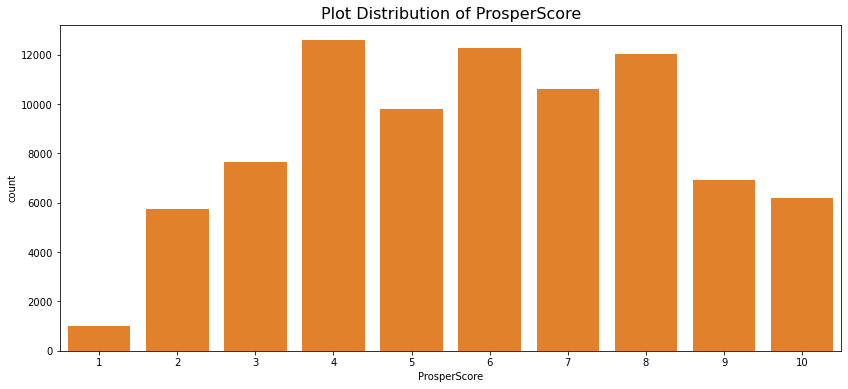

```python
hist(df,"ProsperScore","ProsperScore","Plot Distribution of ProsperScore")
```

**The above graph shows that the most people that obtain loan have ProsperScore between 4 and 8**

```python
# check the data of our independent variable (IncomeRange)
df['IncomeRange'].head(10)
```

```
1     $50,000-74,999
3     $25,000-49,999
4          $100,000+
5          $100,000+
6     $25,000-49,999
7     $25,000-49,999
8     $25,000-49,999
9     $25,000-49,999
10    $75,000-99,999
12    $25,000-49,999
Name: IncomeRange, dtype: object
```

```python
# examine the variable for missing values
df['IncomeRange'].isnull().sum()
```

```
0
```

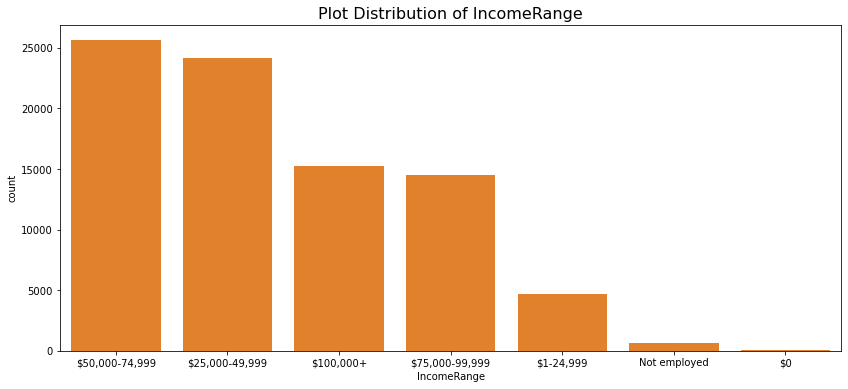

```python
hist(df,"IncomeRange","IncomeRange","Plot Distribution of IncomeRange")
```

**The above graph plot indicated that people with IncomeRange of '$25,000 and $74,999' receive most loans.**

```python
# check the data of our independent variable (IncomeVerifiable)
df['IncomeVerifiable'].head(10)
```

```
1     True
3     True
4     True
5     True
6     True
7     True
8     True
9     True
10    True
12    True
Name: IncomeVerifiable, dtype: bool
```

```python
# examine the variable for missing values
df['IncomeVerifiable'].isnull().sum()
```

```
0
```

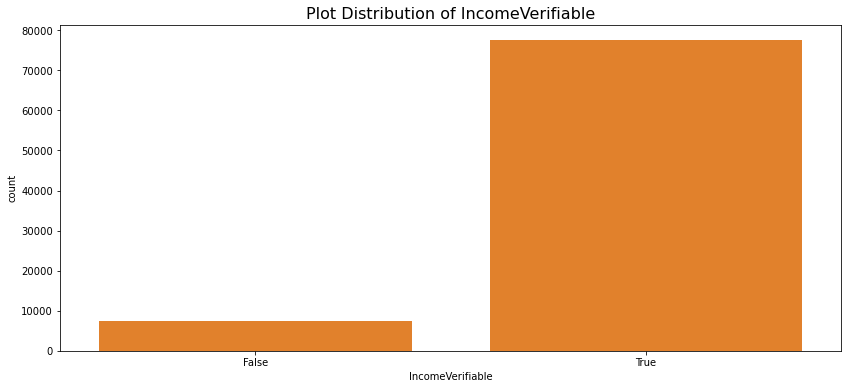

```python
hist(df,"IncomeVerifiable", "IncomeVerifiable","Plot Distribution of IncomeVerifiable")
```

```python
# check the data of our independent variable (EmploymentStatus)
df['EmploymentStatus'].head(10)
```

```
1     Employed
3     Employed
4     Employed
5     Employed
6     Employed
7     Employed
8     Employed
9     Employed
10    Employed
12    Employed
Name: EmploymentStatus, dtype: object
```

```python
# examine the variable for missing values
df['EmploymentStatus'].isnull().sum()
```

```
0
```

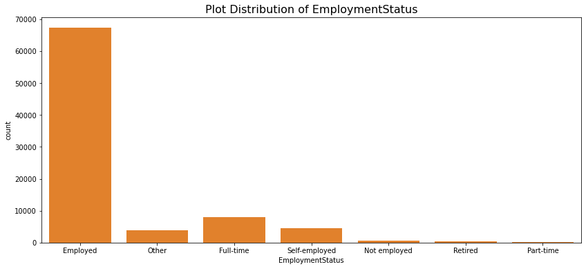

```python
# Plot a graph distribution
hist(df,"EmploymentStatus","EmploymentStatus","Plot Distribution of EmploymentStatus")
```